# R Notebook

My attempt at the BikeShare Linear Regression Machine Learning Project

Read in bikeshare.csv file and set it to a dataframe called bike.

```r
bike <- read.csv('~/Documents/R-Course-HTML-Notes/R-for-Data-Science-and-Machine-Learning/Training Exercises/Machine Learning Projects/CSV files for ML Projects/bikeshare.csv')
```

Check the head of df

```r
print(head(bike))
```

```
##              datetime season holiday workingday weather temp  atemp
## 1 2011-01-01 00:00:00      1       0          0       1 9.84 14.395
## 2 2011-01-01 01:00:00      1       0          0       1 9.02 13.635
## 3 2011-01-01 02:00:00      1       0          0       1 9.02 13.635
## 4 2011-01-01 03:00:00      1       0          0       1 9.84 14.395
## 5 2011-01-01 04:00:00      1       0          0       1 9.84 14.395
## 6 2011-01-01 05:00:00      1       0          0       2 9.84 12.880
##   humidity windspeed casual registered count
## 1       81    0.0000      3         13    16
## 2       80    0.0000      8         32    40
## 3       80    0.0000      5         27    32
## 4       75    0.0000      3         10    13
## 5       75    0.0000      0          1     1
## 6       75    6.0032      0          1     1
```

```r
print(str(bike))
```

```
## 'data.frame':    10886 obs. of  12 variables:
##  $ datetime  : Factor w/ 10886 levels "2011-01-01 00:00:00",..: 1 2 3 4 5 6 7 8 9 10 ...
##  $ season    : int  1 1 1 1 1 1 1 1 1 1 ...
##  $ holiday   : int  0 0 0 0 0 0 0 0 0 0 ...
##  $ workingday: int  0 0 0 0 0 0 0 0 0 0 ...
##  $ weather   : int  1 1 1 1 1 2 1 1 1 1 ...
##  $ temp      : num  9.84 9.02 9.02 9.84 9.84 ...
##  $ atemp     : num  14.4 13.6 13.6 14.4 14.4 ...
##  $ humidity  : int  81 80 80 75 75 75 80 86 75 76 ...
##  $ windspeed : num  0 0 0 0 0 ...
##  $ casual    : int  3 8 5 3 0 0 2 1 1 8 ...
##  $ registered: int  13 32 27 10 1 1 0 2 7 6 ...
##  $ count     : int  16 40 32 13 1 1 2 3 8 14 ...
## NULL
```

**Create a scatter plot of count vs temp. Set a good alpha value.**

```r
library(ggplot2)
library(plotly)
pl <- ggplot(bike,aes(y=count,x=temp)) + geom_point(aes(color=temp),alpha=0.2)

print(ggplotly(pl))
```

[output not shown]

**Plot count versus datetime as a scatterplot with a color gradient based on temperature.** You’ll need to convert the datetime column into POSIXct before plotting.

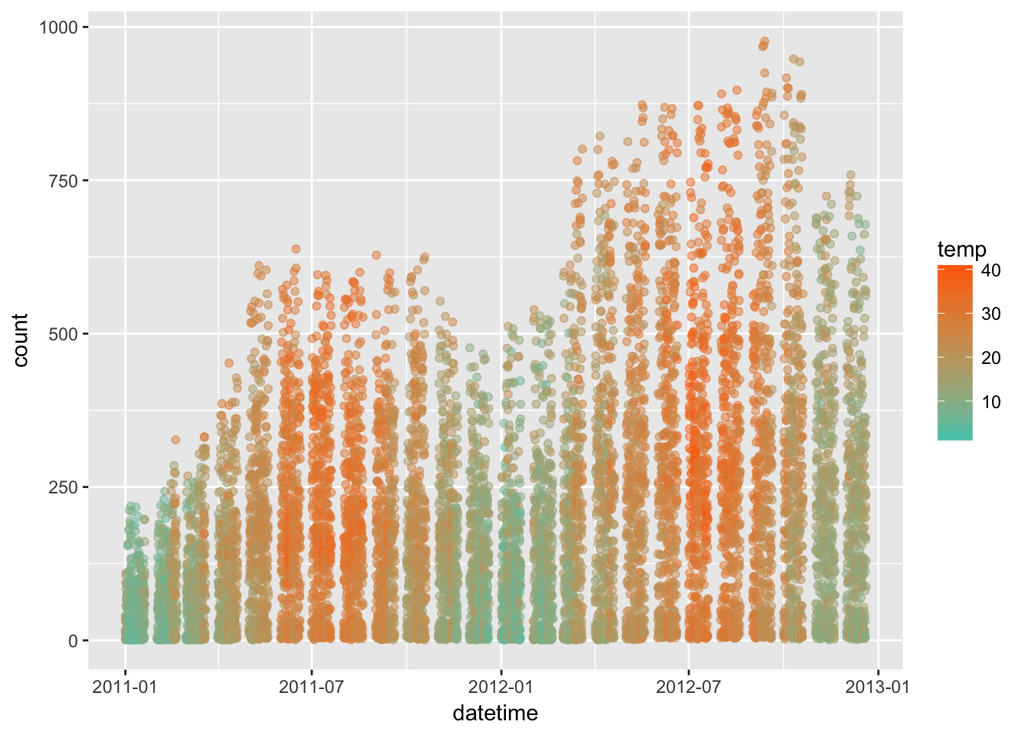

```r
library(ggplot2)
library(plotly)

bike$datetime <- as.POSIXct(as.character(bike$datetime),format = "%Y-%m-%d %H:%M:%S")

pl <- ggplot(bike,aes(y=count,x=datetime)) + geom_point(aes(color=temp),alpha=0.5) + scale_color_gradient(low = '#4ACABB' ,high = '#ff6b00')

print(pl)
```

**What is the correlation between temp and count?**

```r
library(corrgram)
```

```r
library(corrplot)

cor.data <- cor(bike[,c('temp','count')])

print(cor.data)
```

```
##            temp     count
## temp  1.0000000 0.3944536
## count 0.3944536 1.0000000
```

Let’s explore the season data. **Create a boxplot, with the y axis indicating count and the x axis begin a box for each season.**

```r
library(ggplot2)
library(plotly)

pl <- ggplot(bike,aes(y = count,x = factor(season))) + geom_boxplot(aes(color = factor(season)))

print(ggplotly(pl))
```

[output not shown]

**Feature Engineering**

A lot of times you’ll need to use domain knowledge and experience to engineer and create new features. Let’s go ahead and engineer some new features from the datetime column. Create an “hour” column that takes the hour from the datetime column. You’ll probably need to apply some function to the entire datetime column and reassign it. Hint: time.stamp <- bike$datetime[4] format(time.stamp, “%H”)

```r
bike$hour <- format(bike$datetime, '%H')

print(head(bike))
```

```
##              datetime season holiday workingday weather temp  atemp
## 1 2011-01-01 00:00:00      1       0          0       1 9.84 14.395
## 2 2011-01-01 01:00:00      1       0          0       1 9.02 13.635
## 3 2011-01-01 02:00:00      1       0          0       1 9.02 13.635
## 4 2011-01-01 03:00:00      1       0          0       1 9.84 14.395
## 5 2011-01-01 04:00:00      1       0          0       1 9.84 14.395
## 6 2011-01-01 05:00:00      1       0          0       2 9.84 12.880
##   humidity windspeed casual registered count hour
## 1       81    0.0000      3         13    16   00
## 2       80    0.0000      8         32    40   01
## 3       80    0.0000      5         27    32   02
## 4       75    0.0000      3         10    13   03
## 5       75    0.0000      0          1     1   04
## 6       75    6.0032      0          1     1   05
```

**Now create a scatterplot of count versus hour, with color scale based on temp. Only use bike data where workingday==1.**

Optional Additions: Use the additional layer: scale_color_gradientn(colors=c(‘color1’,color2,etc..)) where the colors argument is a vector gradient of colors you choose, not just high and low. Use position=position_jitter(w=1, h=0) inside of geom_point() and check out what it does.

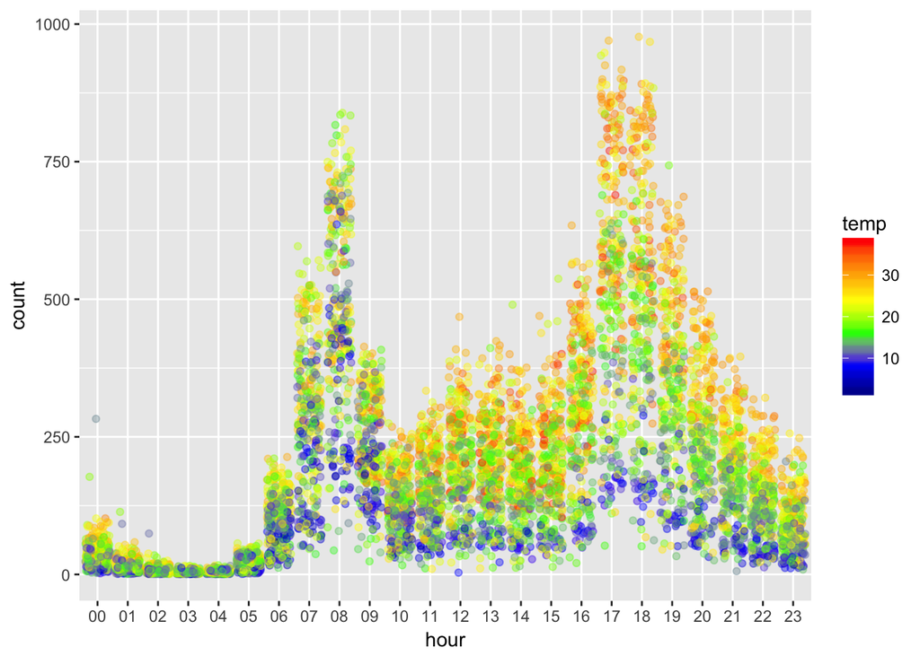

```r
library(ggplot2)
library(plotly)
library(dplyr)
pl <- ggplot(filter(bike,workingday == 1),aes(y = count,x = hour)) + geom_jitter(aes(color = temp),alpha = 0.4) + scale_color_gradientn(colours = c('dark blue','blue','green','yellow','orange','red'),guide = 'colourbar')

print(pl)
```

**Now create the same plot for non working days:**

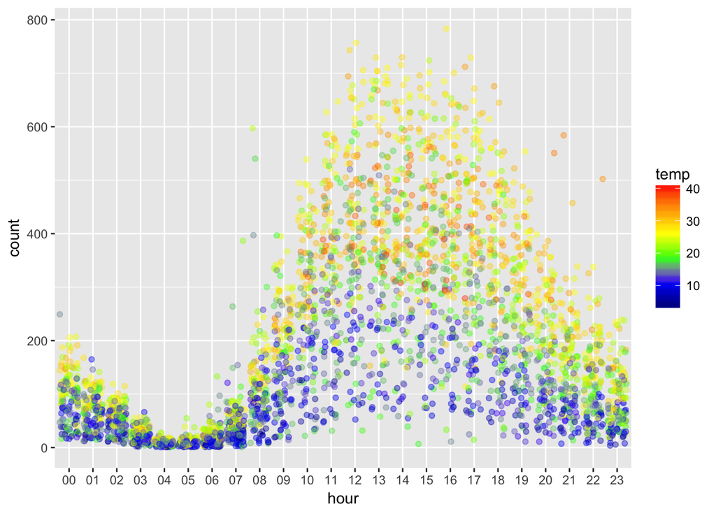

```r
library(ggplot2)
library(plotly)
library(dplyr)

pl <- ggplot(filter(bike,workingday == 0),aes(y = count,x = hour)) + geom_jitter(aes(color = temp),alpha = 0.4) + scale_color_gradientn(colours = c('dark blue','blue','green','yellow','orange','red'),guide = 'colourbar')

print(pl)
```

ou should have noticed that working days have peak activity during the morning (~8am) and right after work gets out (~5pm), with some lunchtime activity. While the non-work days have a steady rise and fall for the afternoon Now let’s continue by trying to build a model, we’ll begin by just looking at a single feature.

**Building the Model**

**Use lm() to build a model that predicts count based solely on the temp feature, name it temp.model**

```r
temp.model <- lm(count ~ temp,data = bike)
```

**Get the summary of the temp.model**

```r
print(summary(temp.model))
```

```
##
## Call:
## lm(formula = count ~ temp, data = bike)
##
## Residuals:
##     Min      1Q  Median      3Q     Max
## -293.32 -112.36  -33.36   78.98  741.44
##
## Coefficients:
##             Estimate Std. Error t value Pr(>|t|)
## (Intercept)   6.0462     4.4394   1.362    0.173
## temp          9.1705     0.2048  44.783   <2e-16 ***
## ---
## Signif. codes:  0 '***' 0.001 '**' 0.01 '*' 0.05 '.' 0.1 ' ' 1
##
## Residual standard error: 166.5 on 10884 degrees of freedom
## Multiple R-squared:  0.1556, Adjusted R-squared:  0.1555
## F-statistic:  2006 on 1 and 10884 DF,  p-value: < 2.2e-16
```

**How many bike rentals would we predict if the temperature was 25 degrees Celsius? Calculate this two ways:**

Using the values we just got above: 1. Using the predict() function 2. You should get around 235.3 bikes.

```r
coef <- as.data.frame(coefficients(temp.model))
check_temp <- 25
count1 <- coef[1,1] + coef[2,1]*check_temp
print(paste('Method 1: Count of Bikes at temp 25 Degree Celcius =',round(count1,4)))
```

```
## [1] "Method 1: Count of Bikes at temp 25 Degree Celcius = 235.3097"
```

```r
check.tempdf <- data.frame(temp = 25)
count2 <- predict(temp.model,check.tempdf)
print(paste('Method 2: Count of Bikes at temp 25 Degree Celcius =',round(count2,4)))
```

```
## [1] "Method 2: Count of Bikes at temp 25 Degree Celcius = 235.3097"
```

**Use sapply() and as.numeric to change the hour column to a column of numeric values.**

```r
bike$hour <- sapply(bike$hour,as.numeric)

print(str(bike))
```

```
## 'data.frame':    10886 obs. of  13 variables:
##  $ datetime  : POSIXct, format: "2011-01-01 00:00:00" "2011-01-01 01:00:00" ...
##  $ season    : int  1 1 1 1 1 1 1 1 1 1 ...
##  $ holiday   : int  0 0 0 0 0 0 0 0 0 0 ...
##  $ workingday: int  0 0 0 0 0 0 0 0 0 0 ...
##  $ weather   : int  1 1 1 1 1 2 1 1 1 1 ...
##  $ temp      : num  9.84 9.02 9.02 9.84 9.84 ...
##  $ atemp     : num  14.4 13.6 13.6 14.4 14.4 ...
##  $ humidity  : int  81 80 80 75 75 75 80 86 75 76 ...
##  $ windspeed : num  0 0 0 0 0 ...
##  $ casual    : int  3 8 5 3 0 0 2 1 1 8 ...
##  $ registered: int  13 32 27 10 1 1 0 2 7 6 ...
##  $ count     : int  16 40 32 13 1 1 2 3 8 14 ...
##  $ hour      : num  0 1 2 3 4 5 6 7 8 9 ...
## NULL
```

```r
final.model <- lm(formula = count ~ . - casual - registered - datetime - atemp, data = bike)
```

**Get the summary of the model**

```r
print(summary(final.model))
```

```
##
## Call:
## lm(formula = count ~ . - casual - registered - datetime - atemp,
##     data = bike)
##
## Residuals:
##     Min      1Q  Median      3Q     Max
## -324.61  -96.88  -31.01   55.27  688.83
##
## Coefficients:
##              Estimate Std. Error t value Pr(>|t|)
## (Intercept)  46.91369    8.45147   5.551 2.91e-08 ***
## season       21.70333    1.35409  16.028  < 2e-16 ***
## holiday     -10.29914    8.79069  -1.172    0.241
## workingday   -0.71781    3.14463  -0.228    0.819
## weather      -3.20909    2.49731  -1.285    0.199
## temp          7.01953    0.19135  36.684  < 2e-16 ***
## humidity     -2.21174    0.09083 -24.349  < 2e-16 ***
## windspeed     0.20271    0.18639   1.088    0.277
## hour          7.61283    0.21688  35.102  < 2e-16 ***
## ---
## Signif. codes:  0 '***' 0.001 '**' 0.01 '*' 0.05 '.' 0.1 ' ' 1
##
## Residual standard error: 147.8 on 10877 degrees of freedom
## Multiple R-squared:  0.3344, Adjusted R-squared:  0.3339
## F-statistic:   683 on 8 and 10877 DF,  p-value: < 2.2e-16
```

**Optional: See how well you can predict for future data points by creating a train/test split. But instead of a random split, your split should be “future” data for test, “previous” data for train.**

```r
library(caTools)

previous <- filter(bike,datetime < '2012-07-01')
future <- filter(bike,datetime >= '2012-07-01')

prev.model <- lm(formula = count ~ . - casual - registered - datetime - atemp, data = previous)

print(summary(prev.model))
```

```
##
## Call:
## lm(formula = count ~ . - casual - registered - datetime - atemp,
##     data = previous)
##
## Residuals:
##     Min      1Q  Median      3Q     Max
## -287.49  -84.46  -26.14   48.31  597.05
##
## Coefficients:
##              Estimate Std. Error t value Pr(>|t|)
## (Intercept)  64.54622    8.23422   7.839 5.12e-15 ***
## season        1.87088    1.50611   1.242 0.214202
## holiday     -18.72340    9.34030  -2.005 0.045041 *
## workingday   -5.87368    3.21801  -1.825 0.067999 .
## weather      -9.05771    2.55596  -3.544 0.000397 ***
## temp          7.61656    0.20676  36.837  < 2e-16 ***
## humidity     -1.73987    0.09150 -19.015  < 2e-16 ***
## windspeed     0.02006    0.18607   0.108 0.914134
## hour          6.55354    0.22217  29.498  < 2e-16 ***
## ---
## Signif. codes:  0 '***' 0.001 '**' 0.01 '*' 0.05 '.' 0.1 ' ' 1
##
## Residual standard error: 131 on 8142 degrees of freedom
## Multiple R-squared:  0.338,  Adjusted R-squared:  0.3373
## F-statistic: 519.5 on 8 and 8142 DF,  p-value: < 2.2e-16
```

**Check the model against future data:**

```r
count.pred <- predict(prev.model,future)
results <- data.frame(predicted = count.pred,actual = future$count)

print(head(results))
```

```
##   predicted actual
## 1  183.6018    149
## 2  177.1308     93
## 3  170.4192     90
## 4  159.6342     33
## 5  168.7217      4
## 6  168.9094     10
```

**Calculating Performance Measures of our model based on future values:**

```r
mse <- mean((results$predicted-results$actual)^2)
rmse <- mse^0.5

SSE <- sum((results$predicted-results$actual)^2)
SST <- sum((mean(bike$count) - results$actual)^2)

R2 <- 1- SSE/SST

print(paste('Mean Squared Error = ',round(mse,4)))
```

```
## [1] "Mean Squared Error =  39192.4679"
```

```r
print(paste('Root Mean Squared Error = ',round(rmse,4)))
```

```
## [1] "Root Mean Squared Error =  197.9709"
```

```r
print(paste('R Squared = ',round(R2,4)))
```

```
## [1] "R Squared =  0.2426"
```